# Algorytm Monte Carlo - przybliżanie wartość liczby $\pi$

```python
import numpy as np
import matplotlib.pyplot as plt
```

## Funkcja do estymacji $\pi$

- Generuje N losowych punktów x, y w zakresie [0,1] × [0,1].
- Sprawdza, czy dany punkt znajduje się wewnątrz ćwiartki okręgu o promieniu 1, korzystając z nierówności: $y \leq \sqrt{1 - x^2}$
- Zlicza punkty wewnątrz i na zewnątrz okręgu, zapisując je w osobnych listach.
- Oblicza estymację wartości π na podstawie stosunku liczby punktów wewnętrznych do wszystkich losowań: $\pi \approx 4 \times \frac{\text{liczba punktów wewnątrz ćwiartki}}{\text{liczba wszystkich punktów}}$
- Zwraca listę punktów wewnątrz, na zewnątrz oraz listę kolejnych estymacji π.

```python
def monte_carlo_pi(N):

    #generowanie N par liczb x, y w zakresie [0,1] x [0,1]
    x = np.random.rand(N)
    y = np.random.rand(N)

    inside = 0  #licznik punktów wewnątrz okręgu
    pi_estimate = []  #lista do przechowywania estymacji π po każdej iteracji

    #przechowywanie informacji o punktach wewnątrz i na zewnątrz okręgu
    inside_points = []
    outside_points = []

    for i in range(N):
        if y[i] <= np.sqrt(1 - x[i]**2):   #sprawdzenie czy punkt leży wewnątrz okręgu
            inside += 1
            inside_points.append((x[i], y[i]))
        else:
            outside_points.append((x[i], y[i]))

        pi_estimate.append((inside / (i+1)) * 4)  #estymacja pi po i-tym punkcie

    return inside_points, outside_points, pi_estimate


# Wartości N do analizy
N_values = [100, 1000, 10000, 100000]
```

## Wykres losowanych punktów dla różnych N

- Tworzone są wykresy pokazujące rozmieszczenie punktów dla różnych wartości N = [100, 1000, 10000, 100000].
- Punkty wewnątrz okręgu są oznaczone na niebiesko, a punkty na zewnątrz – na czerwono.
- Dodatkowo na wykresie rysowana jest ćwiartka okręgu.

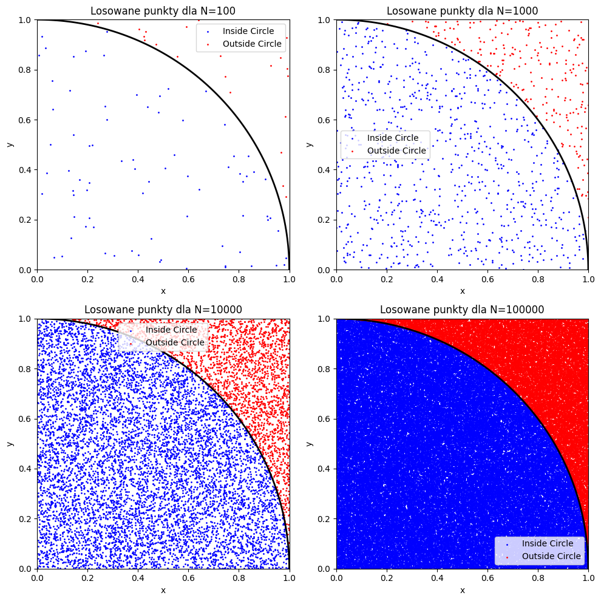

```python
fig, axes = plt.subplots(2, 2, figsize=(10, 10))

for ax, N in zip(axes.flatten(), N_values):
    inside_points, outside_points, _ = monte_carlo_pi(N)

    if inside_points:
        inside_x, inside_y = zip(*inside_points)
    else:
        inside_x, inside_y = [], []

    if outside_points:
        outside_x, outside_y = zip(*outside_points)
    else:
        outside_x, outside_y = [], []

    #scatter plot dla punktów wewnątrz okręgu i na zewnątrz
    ax.scatter(inside_x, inside_y, color='blue', s=1, label='Inside Circle')
    ax.scatter(outside_x, outside_y, color='red', s=1, label='Outside Circle')

    #linia ćwiartki okręgu
    theta = np.linspace(0, np.pi/2, 100)
    ax.plot(np.cos(theta), np.sin(theta), color='black', linewidth=2)

    ax.set_xlim(0, 1)
    ax.set_ylim(0, 1)
    ax.set_xlabel('x')
    ax.set_ylabel('y')
    ax.set_title(f'Losowane punkty dla N={N}')
    ax.legend()

plt.tight_layout()
plt.show()
```

## Wykres ścieżki estymacji $\pi$ dla różnych wartości N

- Tworzony jest wykres ilustrujący, jak zmienia się estymowana wartość π w miarę zwiększania liczby losowań N.
- Widać jak wraz ze wzrostem N wartość estymacji stabilizuje się wokół rzeczywistej wartości π.

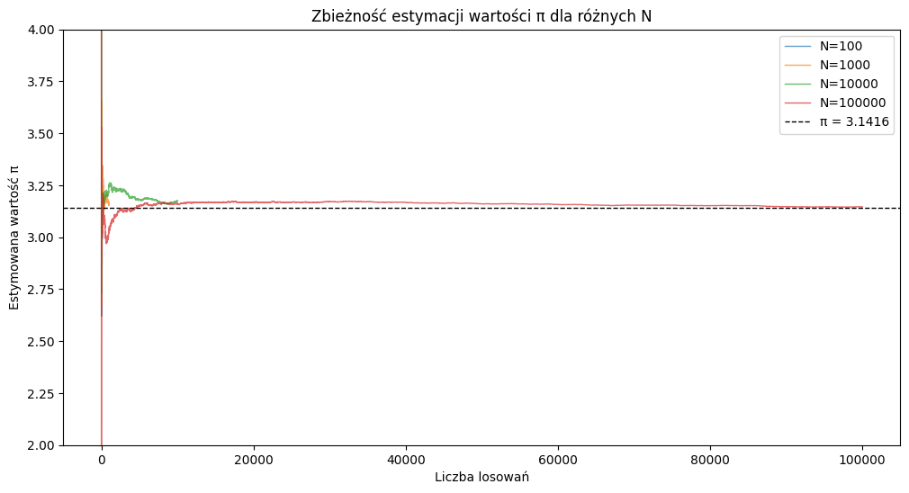

```python
plt.figure(figsize=(12,6))

for N in N_values:
    _, _, pi_estimate = monte_carlo_pi(N)
    plt.plot(pi_estimate, alpha=0.7, linewidth=1, label=f'N={N}')

plt.axhline(y=np.pi, color='black',linewidth=1, linestyle='--', label='π = 3.1416')

plt.xlabel('Liczba losowań')
plt.ylabel('Estymowana wartość π')
plt.ylim(2.0, 4.0)
plt.title('Zbieżność estymacji wartości π dla różnych N')
plt.legend()
plt.show()
```

## Wykresy ścieżkek estymacji $\pi$ dla wielokrotne (10-krotne) uruchomienego eksperymentu dla różnych wartości N

- Wykonywane jest 10 niezależnych symulacji dla każdej wartości N.
- Widać jak estymacje wartości π różnią się między eksperymentami, podkreślając wpływ losowości.

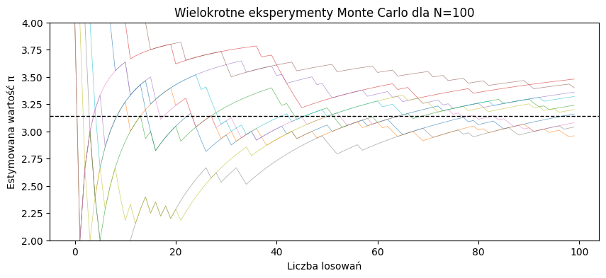

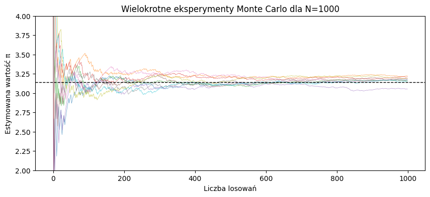

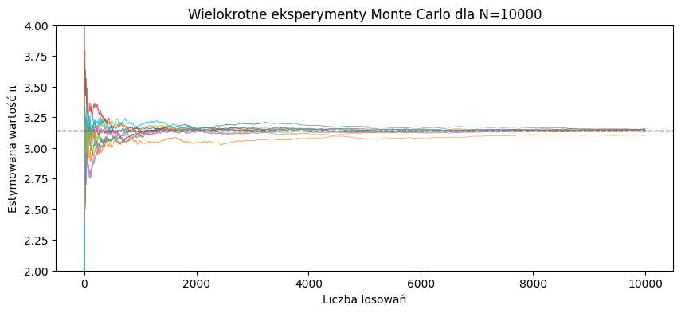

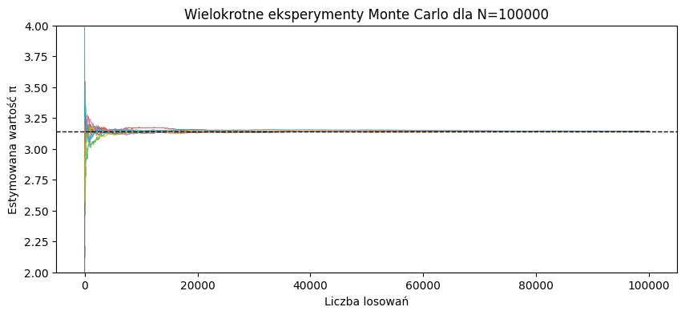

```python
num_experiments = 10

for N in N_values:
    plt.figure(figsize=(10,4))
    for _ in range(num_experiments):
        _, _, pi_estimate = monte_carlo_pi(N)
        plt.plot(pi_estimate, alpha=0.7, linewidth=0.5)

    plt.axhline(y=np.pi, color='black', linewidth=1, linestyle='--', label='π = 3.1416')

    plt.ylim(2.0, 4.0)
    plt.xlabel('Liczba losowań')
    plt.ylabel('Estymowana wartość π')
    plt.title(f'Wielokrotne eksperymenty Monte Carlo dla N={N}')
    plt.show()
```

## Analiza statystyczna jakości estymacji dla różnych N

- Tworzone są wykresy pudełkowe (boxploty), które pokazują rozkład estymowanych wartości π w serii 10 eksperymentów dla każdej z badanych wartości N.
- Czerwona linia na wykresach oznacza medianę, a niebieskie pudełka pokazują rozrzut wartości estymacji.

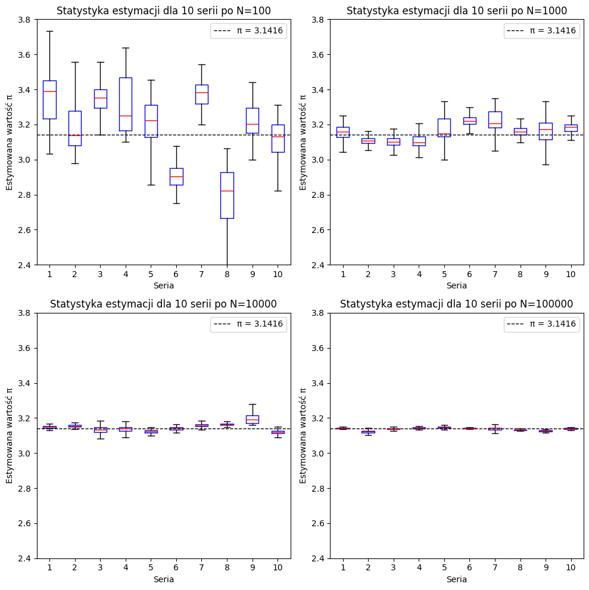

```python
fig, axes = plt.subplots(2, 2, figsize=(10, 10))

for ax, N in zip(axes.flatten(), N_values):
    #zebanie wszystkich estymacji pi w trakcie eksperymentu dla danego N
    pi_estimations = [monte_carlo_pi(N)[2] for _ in range(num_experiments)]

    ax.boxplot(pi_estimations, boxprops=dict(color='blue'), medianprops=dict(color='red', linewidth=1), showfliers=False)

    ax.axhline(y=np.pi, color='black', linewidth=1, linestyle='--', label='π = 3.1416')
    ax.set_ylim(2.4, 3.8)
    ax.set_title(f'Statystyka estymacji dla {num_experiments} serii po N={N}')
    ax.set_ylabel('Estymowana wartość π')
    ax.set_xlabel('Seria')
    ax.legend()

plt.tight_layout()
plt.show()
```

## Wnioski

### Zbieżność estymacji

- Dla małych wartości N estymacja π jest bardzo niestabilna i może znacząco odbiegać od rzeczywistej wartości.
- Wraz ze wzrostem N wartości estymacji zbliżają się do π, co pokazuje prawo wielkich liczb.

### Wpływ losowości

- Wielokrotne eksperymenty dla tego samego N pokazują, że estymacje π mogą się różnić między próbami.
- Różnice te są większe dla małych N, a dla dużych N różnice stają się dużo miniejsze.

### Analiza statystyczna

- Boxploty pokazują, że dla małych N wartości estymacji są szeroko rozproszone, ale dla dużych N rozkład jest coraz bardziej skupiony wokół π.

### Podsumowanie:

Metoda Monte Carlo jest skutecznym sposobem na estymację wartości π. Jej dokładność rośnie wraz z liczbą losowań. Dla N=100000 wyniki są bardzo bliskie rzeczywistej wartości π, natomiast dla małych N wahania są znaczące.